# Match day 8 Season 2627

Liverpool vs Brighton - 25-10-2026

|  | Possession Possession % | Possession On Ball Time | Possession Touches | Possession PKBox Touches | Possession Field Tilt % | Shots Total Shots | Shots OFF Shots | Shots ONT Shots | Shots 6yrd box Shots | Shots PK Box Shots | Shots Outside Box Shots | Shots Blocked Shots | Shots BCs | Shots Goals | Shots xG | Shots NPxG | Shots xGOT | Threat EPV | Threat EPV % xG Con. | Threat EPV % NPxG Con. | Passes Attempted Passes | Passes Successful Passes | Passes Pass Success % | Passes Long Passes | Passes Long Ball Rate | Passes Crosses | Passes Cross Success % | Passes Corners | Passes Short Corners | … |
| --- | --- | --- | --- | --- | --- | --- | --- | --- | --- | --- | --- | --- | --- | --- | --- | --- | --- | --- | --- | --- | --- | --- | --- | --- | --- | --- | --- | --- | --- | --- |
| 1st Quarter |  |  |  |  |  |  |  |  |  |  |  |  |  |  |  |  |  |  |  |  |  |  |  |  |  |  |  |  |  | … |
| Brighton | 48.1% | 11.40 | 186 | 5 | 40.4% | 1 | 1 | 0 | 0 | 1 | 0 | 0 | 1 | 0 | 0.24 | 0.24 | 0.00 | 0.50 | 47.7% | 47.7% | 127 | 92 | 72.4% | 25 | 19.7% | 3 | 0.0% | 0 | 0 | … |
| Liverpool | 51.9% | 11.70 | 201 | 18 | 59.6% | 5 | 2 | 3 | 1 | 5 | 0 | 0 | 1 | 2 | 0.55 | 0.55 | 1.20 | 0.91 | 60.6% | 60.6% | 137 | 94 | 68.6% | 17 | 12.4% | 1 | 0.0% | 0 | 0 | … |
| 2nd Quarter |  |  |  |  |  |  |  |  |  |  |  |  |  |  |  |  |  |  |  |  |  |  |  |  |  |  |  |  |  | … |
| Brighton | 70.0% | 11.70 | 219 | 16 | 76.5% | 7 | 4 | 1 | 0 | 5 | 2 | 2 | 0 | 0 | 0.57 | 0.57 | 0.09 | 0.88 | 64.8% | 64.8% | 169 | 147 | 87.0% | 13 | 7.7% | 7 | 14.3% | 0 | 0 | … |
| Liverpool | 30.0% | 6.70 | 94 | 5 | 23.5% | 4 | 2 | 1 | 1 | 3 | 1 | 1 | 0 | 0 | 0.23 | 0.23 | 0.05 | 0.32 | 71.7% | 71.7% | 43 | 30 | 69.8% | 12 | 27.9% | 1 | 100.0% | 1 | 0 | … |
| 3rd Quarter |  |  |  |  |  |  |  |  |  |  |  |  |  |  |  |  |  |  |  |  |  |  |  |  |  |  |  |  |  | … |
| Brighton | 63.6% | 15.70 | 217 | 13 | 69.8% | 4 | 3 | 0 | 0 | 2 | 2 | 1 | 0 | 0 | 0.25 | 0.25 | 0.00 | 0.91 | 27.5% | 27.5% | 155 | 136 | 87.7% | 15 | 9.7% | 9 | 33.3% | 1 | 0 | … |
| Liverpool | 36.4% | 4.90 | 124 | 7 | 30.2% | 2 | 0 | 0 | 1 | 2 | 0 | 2 | 0 | 0 | 0.34 | 0.34 | 0.00 | 0.41 | 82.1% | 82.1% | 71 | 42 | 59.2% | 16 | 22.5% | 3 | 33.3% | 3 | 0 | … |
| 4th Quarter |  |  |  |  |  |  |  |  |  |  |  |  |  |  |  |  |  |  |  |  |  |  |  |  |  |  |  |  |  | … |
| Brighton | 59.8% | 10.80 | 186 | 6 | 64.4% | 5 | 1 | 0 | 1 | 2 | 3 | 4 | 0 | 0 | 0.27 | 0.27 | 0.00 | 0.66 | 41.0% | 41.0% | 128 | 110 | 85.9% | 12 | 9.4% | 4 | 25.0% | 1 | 0 | … |
| Liverpool | 40.2% | 8.70 | 125 | 1 | 35.6% | 2 | 2 | 0 | 0 | 0 | 2 | 0 | 0 | 0 | 0.09 | 0.09 | 0.00 | 0.26 | 35.3% | 35.3% | 75 | 59 | 78.7% | 12 | 16.0% | 0 | 0.0% | 0 | 0 | … |

X @Barts78 · Bluesky @barts78 · Mastodon @DrBarts · GitHub Barts78 · LinkedIn Phil-barter · Data: Opta

**Match Summary - By Game State**

Liverpool vs Brighton - 25-10-2026

|  | Possession Possession % | Possession On Ball Time | Possession Touches | Possession PKBox Touches | Possession Field Tilt % | Shots Total Shots | Shots OFF Shots | Shots SoT | Shots 6yrd box Shots | Shots PK Box Shots | Shots Outside Box Shots | Shots Blocked Shots | Shots BCs | Shots Goals | Shots xG | Shots NPxG | Shots xGOT | Threat EPV | Threat EPV % xG Con. | Threat EPV % NPxG Con. | Passes Attempted Passes | Passes Successful Passes | Passes Pass Success % | Passes Long Passes | Passes Long Ball Rate | Passes Crosses | Passes Cross Success % | Passes Corners | Passes Short Corners | … |
| --- | --- | --- | --- | --- | --- | --- | --- | --- | --- | --- | --- | --- | --- | --- | --- | --- | --- | --- | --- | --- | --- | --- | --- | --- | --- | --- | --- | --- | --- | --- |
| Draw |  |  |  |  |  |  |  |  |  |  |  |  |  |  |  |  |  |  |  |  |  |  |  |  |  |  |  |  |  | … |
| Brighton | 50.4% | 8.40 | 130 | 3 | 40.3% | 1 | 1 | 0 | 0 | 1 | 0 | 0 | 1 | 0 | 0.24 | 0.24 | 0.00 | 0.36 | 67.6% | 67.6% | 93 | 74 | 79.6% | 17 | 18.3% | 2 | 0.0% | 0 | 0 | … |
| Liverpool | 49.6% | 7.10 | 128 | 9 | 59.7% | 2 | 1 | 1 | 0 | 2 | 0 | 0 | 0 | 1 | 0.11 | 0.11 | 0.14 | 0.43 | 25.5% | 25.5% | 91 | 60 | 65.9% | 11 | 12.1% | 1 | 0.0% | 0 | 0 | … |
| Home Garbage Time |  |  |  |  |  |  |  |  |  |  |  |  |  |  |  |  |  |  |  |  |  |  |  |  |  |  |  |  |  | … |
| Brighton | 62.7% | 39.40 | 657 | 37 | 68.4% | 16 | 8 | 1 | 1 | 9 | 7 | 7 | 0 | 0 | 1.09 | 1.09 | 0.09 | 2.58 | 42.3% | 42.3% | 472 | 404 | 85.6% | 45 | 9.5% | 21 | 23.8% | 2 | 0 | … |
| Liverpool | 37.3% | 22.50 | 391 | 18 | 31.6% | 8 | 4 | 1 | 2 | 5 | 3 | 3 | 0 | 0 | 0.66 | 0.66 | 0.05 | 1.21 | 54.5% | 54.5% | 223 | 157 | 70.4% | 44 | 19.7% | 4 | 50.0% | 4 | 0 | … |
| Home Lead |  |  |  |  |  |  |  |  |  |  |  |  |  |  |  |  |  |  |  |  |  |  |  |  |  |  |  |  |  | … |
| Brighton | 45.7% | 1.90 | 21 | 0 | 0.0% | 0 | 0 | 0 | 0 | 0 | 0 | 0 | 0 | 0 | 0.00 | 0.00 | 0.00 | 0.02 | 0.0% | 0.0% | 14 | 7 | 50.0% | 3 | 21.4% | 0 | 0.0% | 0 | 0 | … |
| Liverpool | 54.3% | 2.40 | 25 | 4 | 100.0% | 3 | 1 | 2 | 1 | 3 | 0 | 0 | 1 | 1 | 0.44 | 0.44 | 1.06 | 0.25 | 173.2% | 173.2% | 12 | 8 | 66.7% | 2 | 16.7% | 0 | 0.0% | 0 | 0 | … |

X @Barts78 · Bluesky @barts78 · Mastodon @DrBarts · GitHub Barts78 · LinkedIn Phil-barter · Data: Opta

**Season Summary Tables**

**Season Summary - Full Games**

Up to Liverpool vs Brighton - 25-10-2026

| Possession % | Touches | PKBox Touches | Field Tilt % | Total Shots | OFF Shots | SoT | 6yrd box Shots | PK Box Shots | Outside Box Shots | BCs | Goals | xG | NPxG | xGOT | EPV | EPV % xG Con. | Attempted Passes | Successful Passes | Pass Success % | Long Passes | Long Ball Rate | Crosses | Cross Success % | Corners | Short Corners | Possession Control | Poss Control /100 Touches | EPV % NPxG Con. |
| --- | --- | --- | --- | --- | --- | --- | --- | --- | --- | --- | --- | --- | --- | --- | --- | --- | --- | --- | --- | --- | --- | --- | --- | --- | --- | --- | --- | --- |
| All Oppo |  |  |  |  |  |  |  |  |  |  |  |  |  |  |  |  |  |  |  |  |  |  |  |  |  |  |  |  |
| 47.7% | 4,954 | 202 | 43.5% | 100 | 41 | 24 | 11 | 61 | 39 | 14 | 8 | 9.47 | 8.68 | 8.18 | 15.93 | 59.5% | 3243 | 2590 | 79.9% | 455 | 14.0% | 124 | 20.2% | 33 | 7 | -730 | -14.7 | 54.5% |
| Liverpool |  |  |  |  |  |  |  |  |  |  |  |  |  |  |  |  |  |  |  |  |  |  |  |  |  |  |  |  |
| 52.3% | 5,433 | 205 | 56.5% | 123 | 40 | 39 | 10 | 71 | 52 | 11 | 11 | 11.45 | 10.66 | 11.93 | 18.02 | 63.6% | 3692 | 3076 | 83.3% | 401 | 10.9% | 139 | 19.4% | 38 | 8 | -660 | -12.1 | 59.2% |

X @Barts78 · Bluesky @barts78 · Mastodon @DrBarts · GitHub Barts78 · LinkedIn Phil-barter · Data: Opta

**Season Summary - By Half**

Up to Liverpool vs Brighton - 25-10-2026

|  | Possession Possession % | Possession Touches | Possession PKBox Touches | Possession Field Tilt % | Shots Total Shots | Shots OFF Shots | Shots SoT | Shots 6yrd box Shots | Shots PK Box Shots | Shots Outside Box Shots | Shots BCs | Shots Goals | Shots xG | Shots NPxG | Shots xGOT | Threat EPV | Threat EPV % xG Con. | Threat EPV % NPxG Con. | Passes Attempted Passes | Passes Successful Passes | Passes Pass Success % | Passes Long Passes | Passes Long Ball Rate | Passes Crosses | Passes Cross Success % | Passes Corners | Passes Short Corners | Possession Control | Poss Control /100 Touches | … |
| --- | --- | --- | --- | --- | --- | --- | --- | --- | --- | --- | --- | --- | --- | --- | --- | --- | --- | --- | --- | --- | --- | --- | --- | --- | --- | --- | --- | --- | --- | --- |
| First Half |  |  |  |  |  |  |  |  |  |  |  |  |  |  |  |  |  |  |  |  |  |  |  |  |  |  |  |  |  | … |
| All Oppo | 47.7% | 2,485 | 102 | 41.6% | 47 | 17 | 10 | 7 | 33 | 14 | 7 | 3 | 3.99 | 3.99 | 2.96 | 8.06 | 49.5% | 49.5% | 1639 | 1297 | 79.1% | 232 | 14.2% | 57 | 17.5% | 19 | 5 |  |  | … |
| Liverpool | 52.3% | 2,727 | 96 | 58.4% | 54 | 20 | 17 | 4 | 28 | 26 | 4 | 4 | 3.92 | 3.92 | 4.04 | 8.84 | 44.3% | 44.3% | 1895 | 1553 | 82.0% | 204 | 10.8% | 63 | 19.1% | 20 | 4 | -328 | -12.0 | … |
| Second Half |  |  |  |  |  |  |  |  |  |  |  |  |  |  |  |  |  |  |  |  |  |  |  |  |  |  |  |  |  | … |
| All Oppo | 47.7% | 2,469 | 100 | 45.2% | 53 | 24 | 14 | 4 | 28 | 25 | 7 | 5 | 5.48 | 4.69 | 5.22 | 7.87 | 69.6% | 59.6% | 1604 | 1293 | 80.6% | 223 | 13.9% | 67 | 22.4% | 14 | 2 | -336 | -13.6 | … |
| Liverpool | 52.3% | 2,706 | 109 | 54.8% | 69 | 20 | 22 | 6 | 43 | 26 | 7 | 7 | 7.53 | 6.74 | 7.89 | 9.18 | 82.1% | 73.4% | 1797 | 1523 | 84.8% | 197 | 11.0% | 76 | 19.7% | 18 | 4 | -332 | -12.3 | … |

X @Barts78 · Bluesky @barts78 · Mastodon @DrBarts · GitHub Barts78 · LinkedIn Phil-barter · Data: Opta

**Season Summary - By Game Period**

Up to Liverpool vs Brighton - 25-10-2026

|  | Possession Possession % | Possession Touches | Possession PKBox Touches | Possession Field Tilt % | Shots Total Shots | Shots OFF Shots | Shots ONT Shots | Shots 6yrd box Shots | Shots PK Box Shots | Shots Outside Box Shots | Shots BCs | Shots Goals | Shots xG | Shots NPxG | Shots xGOT | Threat EPV | Threat EPV % xG Con. | Threat EPV % NPxG Con. | Passes Attempted Passes | Passes Successful Passes | Passes Pass Success % | Passes Long Passes | Passes Long Ball Rate | Passes Crosses | Passes Cross Success % | Passes Corners | Passes Short Corners | Possession Control | Poss Control /100 Touches | … |
| --- | --- | --- | --- | --- | --- | --- | --- | --- | --- | --- | --- | --- | --- | --- | --- | --- | --- | --- | --- | --- | --- | --- | --- | --- | --- | --- | --- | --- | --- | --- |
| 0 - 15 |  |  |  |  |  |  |  |  |  |  |  |  |  |  |  |  |  |  |  |  |  |  |  |  |  |  |  |  |  | … |
| All Oppo | 46.8% | 871 | 28 | 41.2% | 10 | 4 | 1 | 1 | 6 | 4 | 4 | 1 | 1.31 | 1.31 | 0.20 | 2.46 | 53.3% | 53.3% | 587 | 444 | 75.6% | 96 | 16.4% | 14 | 7.1% | 4 | 2 |  |  | … |
| Liverpool | 53.2% | 989 | 27 | 58.8% | 11 | 4 | 3 | 0 | 8 | 3 | 0 | 2 | 0.83 | 0.83 | 0.45 | 2.75 | 30.2% | 30.2% | 713 | 552 | 77.4% | 87 | 12.2% | 15 | 13.3% | 5 | 2 | -138 | -14.0 | … |
| 16 - 30 |  |  |  |  |  |  |  |  |  |  |  |  |  |  |  |  |  |  |  |  |  |  |  |  |  |  |  |  |  | … |
| All Oppo | 46.6% | 760 | 33 | 39.6% | 16 | 3 | 3 | 4 | 13 | 3 | 2 | 1 | 1.29 | 1.29 | 1.58 | 2.41 | 53.5% | 53.5% | 476 | 383 | 80.5% | 57 | 12.0% | 22 | 27.3% | 8 | 2 | -120 | -15.8 | … |
| Liverpool | 53.4% | 872 | 35 | 60.4% | 23 | 9 | 8 | 3 | 10 | 13 | 3 | 2 | 1.91 | 1.91 | 3.08 | 3.02 | 63.2% | 63.2% | 599 | 511 | 85.3% | 54 | 9.0% | 21 | 19.1% | 5 | 0 | -79 | -9.1 | … |
| 31 - 45 |  |  |  |  |  |  |  |  |  |  |  |  |  |  |  |  |  |  |  |  |  |  |  |  |  |  |  |  |  | … |
| All Oppo | 49.7% | 854 | 41 | 44.1% | 21 | 10 | 6 | 2 | 14 | 7 | 1 | 1 | 1.39 | 1.39 | 1.18 | 3.19 | 43.6% | 43.6% | 576 | 470 | 81.6% | 79 | 13.7% | 21 | 14.3% | 7 | 1 | -117 | -13.7 | … |
| Liverpool | 50.3% | 866 | 34 | 55.9% | 20 | 7 | 6 | 1 | 10 | 10 | 1 | 0 | 1.18 | 1.18 | 0.51 | 3.07 | 38.4% | 38.4% | 583 | 490 | 84.0% | 63 | 10.8% | 27 | 22.2% | 10 | 2 | -111 | -12.8 | … |
| 46 - 60 |  |  |  |  |  |  |  |  |  |  |  |  |  |  |  |  |  |  |  |  |  |  |  |  |  |  |  |  |  | … |
| All Oppo | 41.7% | 721 | 33 | 31.8% | 14 | 9 | 3 | 1 | 8 | 6 | 2 | 1 | 1.29 | 1.29 | 1.57 | 2.04 | 63.2% | 63.2% | 421 | 317 | 75.3% | 66 | 15.7% | 18 | 16.7% | 3 | 1 | -95 | -13.2 | … |
| Liverpool | 58.3% | 1,007 | 38 | 68.2% | 30 | 8 | 9 | 4 | 19 | 11 | 4 | 3 | 3.91 | 3.91 | 3.22 | 3.86 | 101.2% | 101.2% | 683 | 580 | 84.9% | 66 | 9.7% | 30 | 23.3% | 7 | 1 | -128 | -12.7 | … |
| 61 - 75 |  |  |  |  |  |  |  |  |  |  |  |  |  |  |  |  |  |  |  |  |  |  |  |  |  |  |  |  |  | … |
| All Oppo | 46.9% | 715 | 37 | 48.0% | 18 | 7 | 8 | 1 | 12 | 6 | 3 | 3 | 2.20 | 1.41 | 2.32 | 2.74 | 80.3% | 51.4% | 471 | 383 | 81.3% | 71 | 15.1% | 20 | 35.0% | 4 | 0 | -97 | -13.6 | … |
| Liverpool | 53.1% | 809 | 39 | 52.0% | 17 | 5 | 7 | 1 | 10 | 7 | 0 | 2 | 1.35 | 1.35 | 1.85 | 2.51 | 53.8% | 53.8% | 555 | 473 | 85.2% | 62 | 11.2% | 23 | 8.7% | 7 | 3 | -86 | -10.6 | … |
| 76 - 90 |  |  |  |  |  |  |  |  |  |  |  |  |  |  |  |  |  |  |  |  |  |  |  |  |  |  |  |  |  | … |
| All Oppo | 53.9% | 812 | 26 | 56.7% | 15 | 6 | 2 | 2 | 6 | 9 | 2 | 1 | 1.80 | 1.80 | 1.20 | 2.58 | 69.6% | 69.6% | 563 | 469 | 83.3% | 64 | 11.4% | 26 | 19.2% | 5 | 0 | -112 | -13.8 | … |
| Liverpool | 46.1% | 695 | 21 | 43.3% | 16 | 5 | 3 | 1 | 11 | 5 | 1 | 1 | 1.06 | 1.06 | 1.69 | 2.06 | 51.5% | 51.5% | 444 | 372 | 83.8% | 53 | 11.9% | 15 | 26.7% | 3 | 0 | -101 | -14.5 | … |
| 90 + |  |  |  |  |  |  |  |  |  |  |  |  |  |  |  |  |  |  |  |  |  |  |  |  |  |  |  |  |  | … |
| All Oppo | 53.1% | 221 | 4 | 48.8% | 6 | 2 | 1 | 0 | 2 | 4 | 0 | 0 | 0.19 | 0.19 | 0.13 | 0.50 | 37.9% | 37.9% | 149 | 124 | 83.2% | 22 | 14.8% | 3 | 0.0% | 2 | 1 | -32 | -14.5 | … |
| Liverpool | 46.9% | 195 | 11 | 51.2% | 6 | 2 | 3 | 0 | 3 | 3 | 2 | 1 | 1.21 | 0.42 | 1.13 | 0.75 | 162.0% | 56.2% | 115 | 98 | 85.2% | 16 | 13.9% | 8 | 25.0% | 1 | 0 | -17 | -8.7 | … |

X @Barts78 · Bluesky @barts78 · Mastodon @DrBarts · GitHub Barts78 · LinkedIn Phil-barter · Data: Opta

**Season Summary - By Game State**

Up to Liverpool vs Brighton - 25-10-2026

|  | Possession Possession % | Possession Touches | Possession PKBox Touches | Possession Field Tilt % | Shots Total Shots | Shots OFF Shots | Shots SoT | Shots 6yrd box Shots | Shots PK Box Shots | Shots Outside Box Shots | Shots BCs | Shots Goals | Shots xG | Shots NPxG | Shots xGOT | Threat EPV | Threat EPV % xG Con. | Threat EPV % NPxG Con. | Passes Attempted Passes | Passes Successful Passes | Passes Pass Success % | Passes Long Passes | Passes Long Ball Rate | Passes Crosses | Passes Cross Success % | Passes Corners | Passes Short Corners | Possession Control | Poss Control /100 Touches | … |
| --- | --- | --- | --- | --- | --- | --- | --- | --- | --- | --- | --- | --- | --- | --- | --- | --- | --- | --- | --- | --- | --- | --- | --- | --- | --- | --- | --- | --- | --- | --- |
| Away Garbage Time |  |  |  |  |  |  |  |  |  |  |  |  |  |  |  |  |  |  |  |  |  |  |  |  |  |  |  |  |  | … |
| All Oppo | 53.1% | 823 | 29 | 58.7% | 22 | 9 | 6 | 3 | 7 | 15 | 1 | 1 | 1.77 | 1.77 | 1.68 | 2.60 | 68.0% | 68.0% | 609 | 532 | 87.4% | 52 | 8.5% | 17 | 35.3% | 6 | 1 |  |  | … |
| Liverpool | 46.9% | 728 | 17 | 41.3% | 9 | 1 | 6 | 0 | 3 | 6 | 0 | 0 | 0.53 | 0.53 | 2.20 | 2.06 | 25.7% | 25.7% | 508 | 444 | 87.4% | 57 | 11.2% | 9 | 22.2% | 3 | 0 | -65 | -8.9 | … |
| Away Lead |  |  |  |  |  |  |  |  |  |  |  |  |  |  |  |  |  |  |  |  |  |  |  |  |  |  |  |  |  | … |
| All Oppo | 43.9% | 702 | 25 | 38.1% | 10 | 5 | 3 | 1 | 7 | 3 | 0 | 1 | 0.78 | 0.78 | 1.03 | 2.30 | 33.9% | 33.9% | 407 | 310 | 76.2% | 72 | 17.7% | 23 | 21.7% | 3 | 0 | -93 | -13.2 | … |
| Liverpool | 56.1% | 896 | 30 | 61.9% | 18 | 4 | 8 | 1 | 12 | 6 | 1 | 3 | 2.34 | 2.34 | 2.39 | 3.31 | 70.6% | 70.6% | 607 | 520 | 85.7% | 55 | 9.1% | 28 | 14.3% | 7 | 2 | -108 | -12.1 | … |
| Draw |  |  |  |  |  |  |  |  |  |  |  |  |  |  |  |  |  |  |  |  |  |  |  |  |  |  |  |  |  | … |
| All Oppo | 45.8% | 2,192 | 92 | 40.8% | 39 | 13 | 11 | 5 | 31 | 8 | 11 | 6 | 4.42 | 3.63 | 4.44 | 7.11 | 62.1% | 51.0% | 1433 | 1107 | 77.3% | 224 | 15.6% | 54 | 14.8% | 20 | 6 | -369 | -16.8 | … |
| Liverpool | 54.2% | 2,591 | 87 | 59.2% | 54 | 23 | 13 | 4 | 31 | 23 | 6 | 4 | 4.67 | 4.67 | 3.15 | 8.42 | 55.5% | 55.5% | 1820 | 1500 | 82.4% | 195 | 10.7% | 67 | 16.4% | 15 | 4 | -327 | -12.6 | … |
| Home Garbage Time |  |  |  |  |  |  |  |  |  |  |  |  |  |  |  |  |  |  |  |  |  |  |  |  |  |  |  |  |  | … |
| All Oppo | 62.7% | 657 | 37 | 68.4% | 16 | 8 | 1 | 1 | 9 | 7 | 0 | 0 | 1.09 | 1.09 | 0.09 | 2.58 | 42.3% | 42.3% | 472 | 404 | 85.6% | 45 | 9.5% | 21 | 23.8% | 2 | 0 | -90 | -13.7 | … |
| Liverpool | 37.3% | 391 | 18 | 31.6% | 8 | 4 | 1 | 2 | 5 | 3 | 0 | 0 | 0.66 | 0.66 | 0.05 | 1.21 | 54.5% | 54.5% | 223 | 157 | 70.4% | 44 | 19.7% | 4 | 50.0% | 4 | 0 | -57 | -14.6 | … |
| Home Lead |  |  |  |  |  |  |  |  |  |  |  |  |  |  |  |  |  |  |  |  |  |  |  |  |  |  |  |  |  | … |
| All Oppo | 41.2% | 580 | 19 | 26.8% | 13 | 6 | 3 | 1 | 7 | 6 | 2 | 0 | 1.41 | 1.41 | 0.94 | 1.34 | 105.5% | 105.5% | 322 | 237 | 73.6% | 62 | 19.2% | 9 | 11.1% | 2 | 0 | -94 | -16.2 | … |
| Liverpool | 58.8% | 827 | 53 | 73.2% | 34 | 8 | 11 | 3 | 20 | 14 | 4 | 4 | 3.25 | 2.46 | 4.14 | 3.01 | 108.0% | 81.7% | 534 | 455 | 85.2% | 50 | 9.4% | 31 | 25.8% | 9 | 2 | -103 | -12.5 | … |

X @Barts78 · Bluesky @barts78 · Mastodon @DrBarts · GitHub Barts78 · LinkedIn Phil-barter · Data: Opta

**Season Summary - By Match Day**

Up to Liverpool vs Brighton - 25-10-2026

|  | Fixture | Possession Possession % | Possession Touches | Possession PKBox Touches | Possession Field Tilt % | Shots Total Shots | Shots OFF Shots | Shots SoT | Shots 6yrd box Shots | Shots PK Box Shots | Shots Outside Box Shots | Shots BCs | Shots Goals | Shots xG | Shots NPxG | Shots xGOT | Threat EPV | Threat EPV % xG Con. | Threat EPV % NPxG Con. | Passes Attempted Passes | Passes Successful Passes | Passes Pass Success % | Passes Long Passes | Passes Long Ball Rate | Passes Crosses | Passes Cross Success % | Passes Corners | Passes Short Corners | Possession Control | … |
| --- | --- | --- | --- | --- | --- | --- | --- | --- | --- | --- | --- | --- | --- | --- | --- | --- | --- | --- | --- | --- | --- | --- | --- | --- | --- | --- | --- | --- | --- | --- |
| 1 |  |  |  |  |  |  |  |  |  |  |  |  |  |  |  |  |  |  |  |  |  |  |  |  |  |  |  |  |  | … |
| All Oppo | Newcastle vs Liverpool | 43.8% | 518 | 16 | 31.2% | 13 | 5 | 4 | 1 | 6 | 7 | 3 | 2 | 1.43 | 1.43 | 1.30 | 1.23 | 116.1% | 116.1% | 292 | 222 | 76.0% | 50 | 17.1% | 8 | 12.5% | 2 | 0 |  | … |
| Liverpool | Newcastle vs Liverpool | 56.2% | 666 | 39 | 68.8% | 27 | 4 | 7 | 2 | 16 | 11 | 3 | 2 | 2.74 | 1.95 | 2.73 | 2.24 | 122.3% | 87.1% | 440 | 370 | 84.1% | 47 | 10.7% | 27 | 25.9% | 6 | 0 | -91 | … |
| 2 |  |  |  |  |  |  |  |  |  |  |  |  |  |  |  |  |  |  |  |  |  |  |  |  |  |  |  |  |  | … |
| All Oppo | Liverpool vs Nottingham Forest | 37.2% | 520 | 23 | 28.1% | 12 | 3 | 3 | 3 | 11 | 1 | 5 | 2 | 2.30 | 1.51 | 1.28 | 1.89 | 121.5% | 79.8% | 288 | 193 | 67.0% | 75 | 26.0% | 7 | 28.6% | 5 | 0 | -84 | … |
| Liverpool | Liverpool vs Nottingham Forest | 62.8% | 878 | 23 | 71.9% | 13 | 5 | 4 | 1 | 8 | 5 | 1 | 2 | 1.73 | 1.73 | 2.02 | 3.38 | 51.2% | 51.2% | 631 | 562 | 89.1% | 46 | 7.3% | 30 | 16.7% | 3 | 1 | -97 | … |
| 3 |  |  |  |  |  |  |  |  |  |  |  |  |  |  |  |  |  |  |  |  |  |  |  |  |  |  |  |  |  | … |
| All Oppo | Ipswich vs Liverpool | 45.4% | 620 | 16 | 43.0% | 14 | 5 | 5 | 2 | 4 | 10 | 0 | 0 | 0.76 | 0.76 | 0.76 | 1.92 | 39.6% | 39.6% | 428 | 357 | 83.4% | 41 | 9.6% | 15 | 26.7% | 4 | 0 | -83 | … |
| Liverpool | Ipswich vs Liverpool | 54.6% | 745 | 20 | 57.0% | 10 | 1 | 7 | 0 | 5 | 5 | 0 | 2 | 0.67 | 0.67 | 1.94 | 2.32 | 28.9% | 28.9% | 531 | 471 | 88.7% | 54 | 10.2% | 11 | 27.3% | 3 | 0 | -60 | … |
| 4 |  |  |  |  |  |  |  |  |  |  |  |  |  |  |  |  |  |  |  |  |  |  |  |  |  |  |  |  |  | … |
| All Oppo | Liverpool vs Fulham | 45.6% | 592 | 25 | 36.5% | 10 | 3 | 3 | 0 | 8 | 2 | 1 | 0 | 0.71 | 0.71 | 0.82 | 1.56 | 45.4% | 45.4% | 394 | 303 | 76.9% | 60 | 15.2% | 16 | 18.8% | 8 | 1 | -93 | … |
| Liverpool | Liverpool vs Fulham | 54.4% | 705 | 18 | 63.5% | 14 | 6 | 3 | 2 | 9 | 5 | 4 | 0 | 1.13 | 1.13 | 0.66 | 2.38 | 47.5% | 47.5% | 495 | 413 | 83.4% | 52 | 10.5% | 25 | 20.0% | 5 | 1 | -87 | … |
| 5 |  |  |  |  |  |  |  |  |  |  |  |  |  |  |  |  |  |  |  |  |  |  |  |  |  |  |  |  |  | … |
| All Oppo | Bournemouth vs Liverpool | 46.7% | 612 | 27 | 53.6% | 9 | 5 | 2 | 2 | 5 | 4 | 1 | 0 | 0.76 | 0.76 | 1.04 | 2.59 | 29.4% | 29.4% | 382 | 297 | 77.7% | 53 | 13.9% | 27 | 22.2% | 3 | 1 | -109 | … |
| Liverpool | Bournemouth vs Liverpool | 53.3% | 699 | 19 | 46.4% | 12 | 3 | 3 | 0 | 7 | 5 | 1 | 1 | 1.58 | 1.58 | 1.13 | 2.05 | 77.2% | 77.2% | 474 | 384 | 81.0% | 60 | 12.7% | 13 | 7.7% | 3 | 0 | -86 | … |
| 6 |  |  |  |  |  |  |  |  |  |  |  |  |  |  |  |  |  |  |  |  |  |  |  |  |  |  |  |  |  | … |
| All Oppo | Liverpool vs Man City | 61.2% | 746 | 28 | 62.7% | 15 | 7 | 4 | 1 | 8 | 7 | 2 | 3 | 1.31 | 1.31 | 1.68 | 2.15 | 60.9% | 60.9% | 551 | 489 | 88.7% | 50 | 9.1% | 12 | 16.7% | 6 | 3 | -79 | … |
| Liverpool | Liverpool vs Man City | 38.8% | 473 | 16 | 37.3% | 13 | 3 | 6 | 1 | 6 | 7 | 0 | 0 | 0.87 | 0.87 | 0.93 | 1.39 | 62.5% | 62.5% | 296 | 238 | 80.4% | 40 | 13.5% | 13 | 15.4% | 5 | 0 | -58 | … |
| 7 |  |  |  |  |  |  |  |  |  |  |  |  |  |  |  |  |  |  |  |  |  |  |  |  |  |  |  |  |  | … |
| All Oppo | Brentford vs Liverpool | 42.7% | 538 | 27 | 32.8% | 10 | 4 | 2 | 1 | 9 | 1 | 1 | 1 | 0.87 | 0.87 | 1.21 | 1.63 | 53.3% | 53.3% | 329 | 244 | 74.2% | 61 | 18.5% | 16 | 12.5% | 3 | 2 | -88 | … |
| Liverpool | Brentford vs Liverpool | 57.3% | 723 | 39 | 67.2% | 21 | 12 | 5 | 1 | 10 | 11 | 1 | 2 | 1.52 | 1.52 | 1.27 | 2.37 | 64.2% | 64.2% | 499 | 413 | 82.8% | 45 | 9.0% | 15 | 13.3% | 9 | 6 | -93 | … |
| 8 |  |  |  |  |  |  |  |  |  |  |  |  |  |  |  |  |  |  |  |  |  |  |  |  |  |  |  |  |  | … |
| All Oppo | Liverpool vs Brighton | 59.8% | 808 | 40 | 61.8% | 17 | 9 | 1 | 1 | 10 | 7 | 1 | 0 | 1.33 | 1.33 | 0.09 | 2.95 | 45.1% | 45.1% | 579 | 485 | 83.8% | 65 | 11.2% | 23 | 21.7% | 2 | 0 | -122 | … |
| Liverpool | Liverpool vs Brighton | 40.2% | 544 | 31 | 38.2% | 13 | 6 | 4 | 3 | 10 | 3 | 1 | 2 | 1.21 | 1.21 | 1.25 | 1.90 | 63.8% | 63.8% | 326 | 225 | 69.0% | 57 | 17.5% | 5 | 40.0% | 4 | 0 | -88 | … |

X @Barts78 · Bluesky @barts78 · Mastodon @DrBarts · GitHub Barts78 · LinkedIn Phil-barter · Data: Opta

**Match Goals Probablity xG only**

[figure not shown]

**Match Goals Probablity Blended**

[figure not shown]

**Match Goals Probablity Optimistic**

[figure not shown]

**Match Goals Probablity Pessimistic**

[figure not shown]

**Match Result Probablity - All Models**

[figure not shown]

**Match Result Probablity xG only**

[figure not shown]

**Match Result Probablity Blended**

[figure not shown]

**Match Result Probablity Optimistic**

[figure not shown]

**Match Result Probablity Pessimistic**

[figure not shown]

Home Match territory plot

[figure not shown]

Away Match teratitory plot

[figure not shown]

Substitution Impact

**Substitution Impact - Before and After Each Sub Window**

Liverpool vs Brighton - 25-10-2026 | xG and EPV per 10 minutes, field tilt and PPDA within each window

|  | Mins | Subs on | Score | Liverpool xG/10 | Liverpool EPV/10 | Liverpool Field tilt % | Liverpool PPDA | Brighton xG/10 | Brighton EPV/10 | Brighton Field tilt % | Brighton PPDA |
| --- | --- | --- | --- | --- | --- | --- | --- | --- | --- | --- | --- |
| 0'-5' | 5 | Starting XIs | 0-0 | 0.00 | 0.19 | 56% | - | 0.00 | 0.13 | 44% | 10.00 |
| 5'-49' | 44 | BRI: Costinha | 0-0 | 0.18 | 0.26 | 43% | 17.82 | 0.18 | 0.30 | 57% | 9.82 |
| 49'-57' | 8 | BRI: Hinshelwood | 2-0 | 0.00 | 0.18 | 40% | 11.00 | 0.10 | 0.45 | 60% | 4.14 |
| 57'-68' | 11 | BRI: Yalcouyé | 2-0 | 0.11 | 0.16 | 21% | 46.00 | 0.12 | 0.25 | 79% | 15.00 |
| 68'-78' | 10 | LIV: Nyoni | 2-0 | 0.29 | 0.13 | 30% | 12.67 | 0.04 | 0.32 | 70% | 21.00 |
| 78'-91' | 13 | LIV: Ngumoha, Koumas \| BRI: Rutter | 2-0 | 0.02 | 0.13 | 45% | 17.00 | 0.15 | 0.29 | 55% | 17.50 |
| 91'-98' | 8 | LIV: Tsimikas | 2-0 | 0.00 | 0.07 | 16% | 27.00 | 0.09 | 0.29 | 84% | 8.00 |

Windows split at each substitution (subs within 3 minutes are grouped). Short windows are noisy, so read alongside the minutes column.  
X @Barts78 · Bluesky @barts78 · Mastodon @DrBarts · GitHub Barts78 · LinkedIn Phil-barter · Data: Opta

Match vs Season Average

[figure not shown]

Home Pass Maps

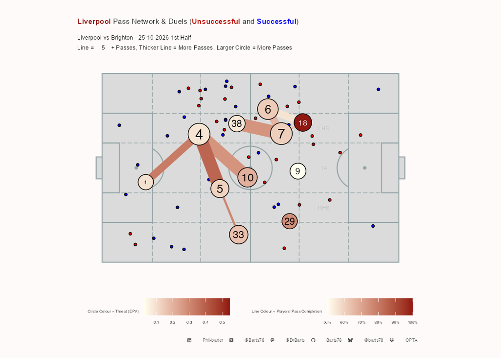

Away Pass Maps

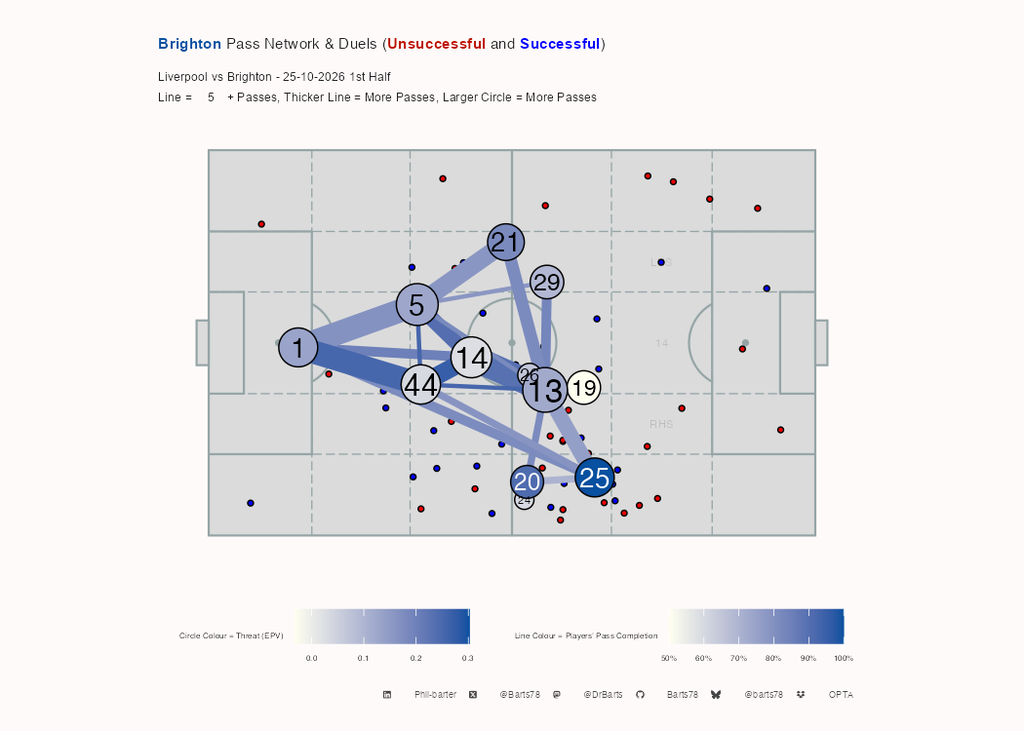

Home Pass Maps by Time

[figure not shown]

Away Pass Maps by Time

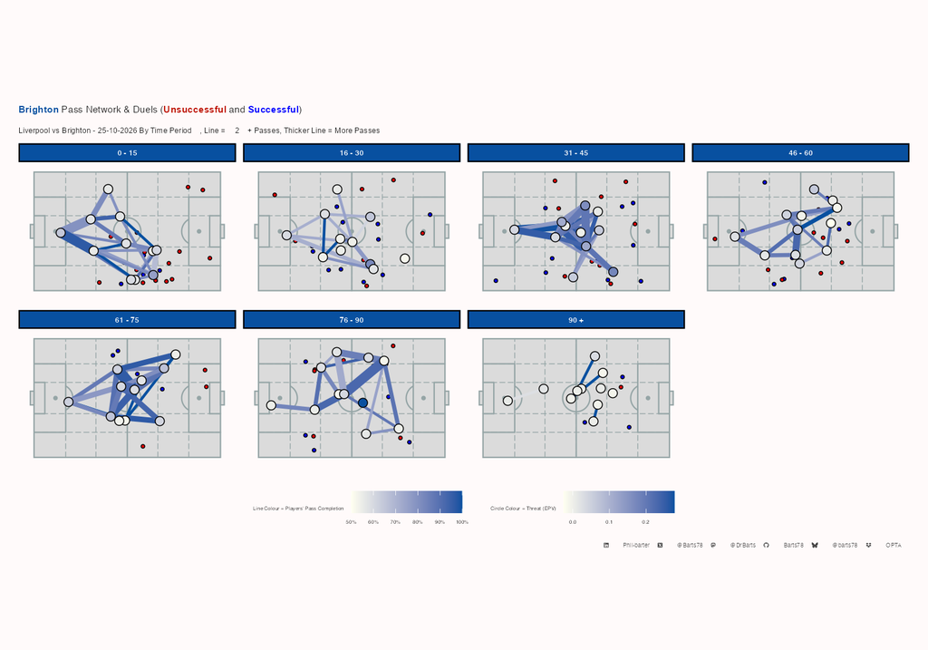

Home Attacking Pass Maps

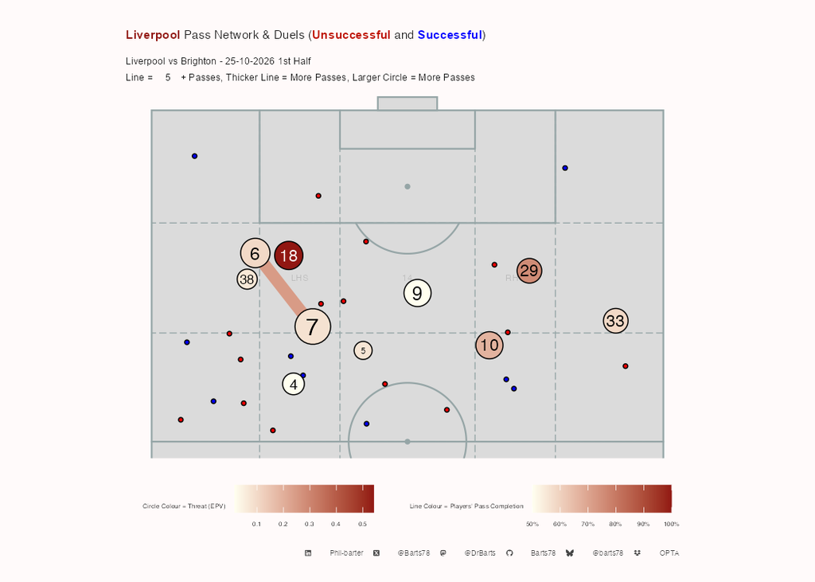

Away Attacking Pass Maps

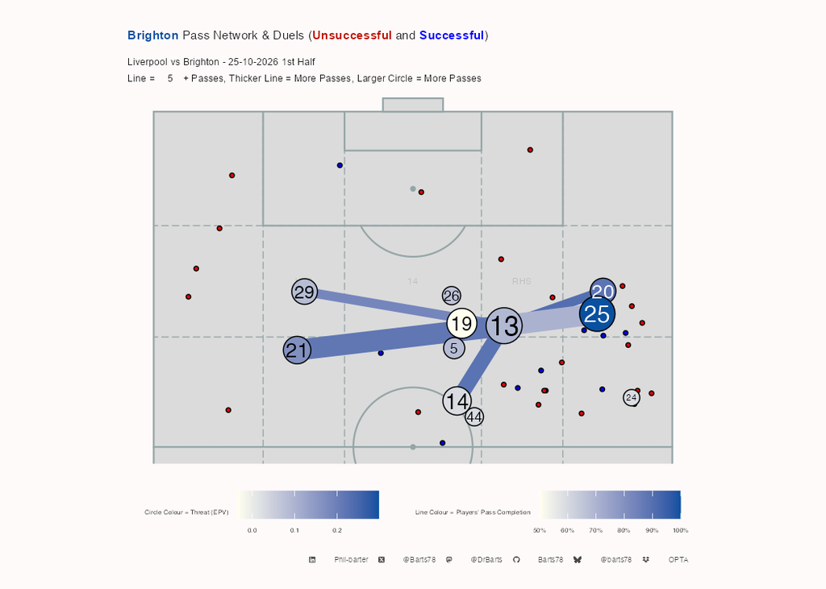

Home Attacking Pass Maps by Time

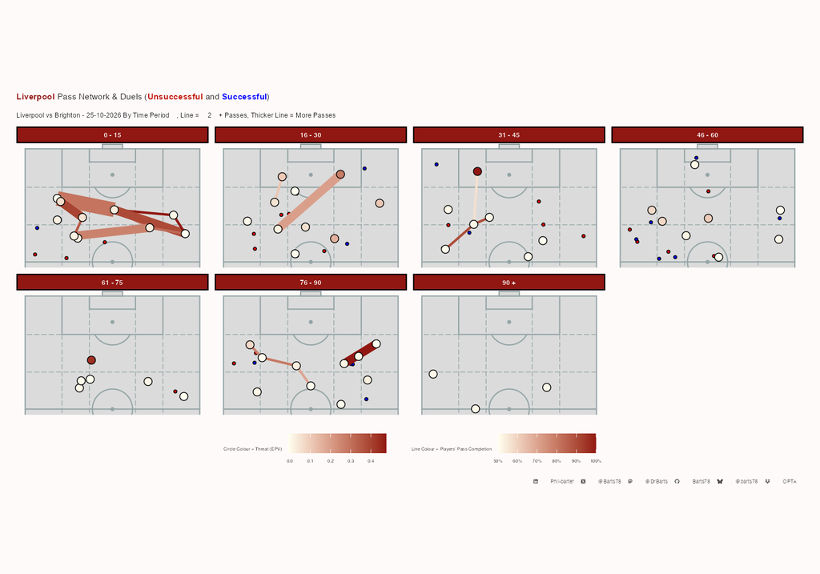

Away Attacking Pass Maps by Time

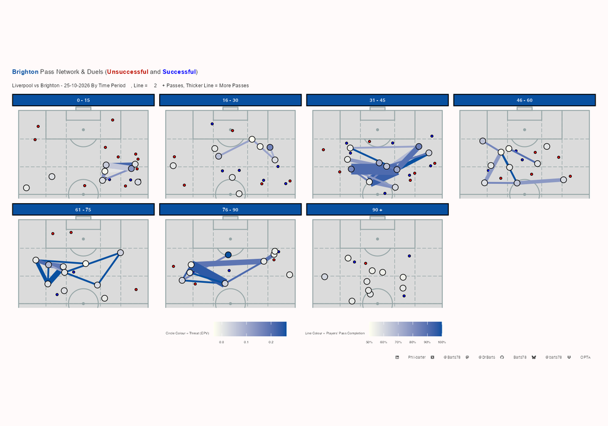

**Pass Connections by Passer**

Liverpool Open Play Passing connections

Liverpool vs Brighton - 25-10-2026 | Completed passes only, min 5 per pair. Passer Completion % = all of the passer's attempts

|  | Completed Passes | % of Passer's Completions | % of Receiver's Receptions | Passer Completion % | Long Passes | Final Third Passes | PK Box Passes | Crosses | Key Passes | Prog Passes | EPV | EPV / Pass | Pass Time |
| --- | --- | --- | --- | --- | --- | --- | --- | --- | --- | --- | --- | --- | --- |
| Alexis Mac Allister |  |  |  |  |  |  |  |  |  |  |  |  |  |
| Virgil van Dijk | 5 | 20% | 33% | 68% | 0 | 1 | 0 | 0 | 0 | 0 | 0.014 | 0.003 | 2.60 |
| Florian Wirtz |  |  |  |  |  |  |  |  |  |  |  |  |  |
| Cody Gakpo | 6 | 22% | 19% | 75% | 3 | 3 | 0 | 0 | 0 | 4 | 0.076 | 0.013 | 4.67 |
| Milos Kerkez | 5 | 18% | 24% | 75% | 0 | 3 | 0 | 0 | 0 | 1 | 0.027 | 0.005 | 2.80 |
| Jérémy Jacquet |  |  |  |  |  |  |  |  |  |  |  |  |  |
| Ronald Araujo | 5 | 24% | 28% | 75% | 0 | 0 | 0 | 0 | 0 | 0 | 0.004 | 0.001 | 2.60 |
| Milos Kerkez |  |  |  |  |  |  |  |  |  |  |  |  |  |
| Cody Gakpo | 8 | 36% | 26% | 67% | 0 | 5 | 0 | 0 | 1 | 2 | 0.051 | 0.006 | 2.00 |
| Ryan Gravenberch |  |  |  |  |  |  |  |  |  |  |  |  |  |
| Florian Wirtz | 6 | 30% | 23% | 80% | 0 | 3 | 0 | 0 | 0 | 1 | 0.034 | 0.006 | 1.50 |
| Virgil van Dijk |  |  |  |  |  |  |  |  |  |  |  |  |  |
| Alisson Becker | 6 | 19% | 38% | 82% | 0 | 0 | 0 | 0 | 0 | 0 | 0.005 | 0.001 | 2.00 |
| Cody Gakpo | 5 | 16% | 16% | 82% | 1 | 0 | 0 | 0 | 0 | 1 | 0.029 | 0.006 | 2.40 |
| Jérémy Jacquet | 5 | 16% | 29% | 82% | 0 | 0 | 0 | 0 | 0 | 0 | 0.007 | 0.001 | 3.00 |
| Ryan Gravenberch | 5 | 16% | 29% | 82% | 0 | 0 | 0 | 0 | 0 | 1 | 0.018 | 0.004 | 3.20 |

X @Barts78 · Bluesky @barts78 · Mastodon @DrBarts · GitHub Barts78 · LinkedIn Phil-barter · Data: Opta

**Pass Connections by Receiver**

Liverpool Open Play Passing connections

Liverpool vs Brighton - 25-10-2026 | Completed passes only, min 5 per pair. Passer Completion % = all of the passer's attempts

|  | Completed Passes | % of Passer's Completions | % of Receiver's Receptions | Passer Completion % | Long Passes | Final Third Passes | PK Box Passes | Crosses | Key Passes | Prog Passes | EPV | EPV / Pass | Pass Time |
| --- | --- | --- | --- | --- | --- | --- | --- | --- | --- | --- | --- | --- | --- |
| Virgil van Dijk |  |  |  |  |  |  |  |  |  |  |  |  |  |
| Alexis Mac Allister | 5 | 20% | 33% | 68% | 0 | 1 | 0 | 0 | 0 | 0 | 0.014 | 0.003 | 2.60 |
| Cody Gakpo |  |  |  |  |  |  |  |  |  |  |  |  |  |
| Florian Wirtz | 6 | 22% | 19% | 75% | 3 | 3 | 0 | 0 | 0 | 4 | 0.076 | 0.013 | 4.67 |
| Milos Kerkez | 8 | 36% | 26% | 67% | 0 | 5 | 0 | 0 | 1 | 2 | 0.051 | 0.006 | 2.00 |
| Virgil van Dijk | 5 | 16% | 16% | 82% | 1 | 0 | 0 | 0 | 0 | 1 | 0.029 | 0.006 | 2.40 |
| Milos Kerkez |  |  |  |  |  |  |  |  |  |  |  |  |  |
| Florian Wirtz | 5 | 18% | 24% | 75% | 0 | 3 | 0 | 0 | 0 | 1 | 0.027 | 0.005 | 2.80 |
| Ronald Araujo |  |  |  |  |  |  |  |  |  |  |  |  |  |
| Jérémy Jacquet | 5 | 24% | 28% | 75% | 0 | 0 | 0 | 0 | 0 | 0 | 0.004 | 0.001 | 2.60 |
| Florian Wirtz |  |  |  |  |  |  |  |  |  |  |  |  |  |
| Ryan Gravenberch | 6 | 30% | 23% | 80% | 0 | 3 | 0 | 0 | 0 | 1 | 0.034 | 0.006 | 1.50 |
| Alisson Becker |  |  |  |  |  |  |  |  |  |  |  |  |  |
| Virgil van Dijk | 6 | 19% | 38% | 82% | 0 | 0 | 0 | 0 | 0 | 0 | 0.005 | 0.001 | 2.00 |
| Jérémy Jacquet |  |  |  |  |  |  |  |  |  |  |  |  |  |
| Virgil van Dijk | 5 | 16% | 29% | 82% | 0 | 0 | 0 | 0 | 0 | 0 | 0.007 | 0.001 | 3.00 |
| Ryan Gravenberch |  |  |  |  |  |  |  |  |  |  |  |  |  |
| Virgil van Dijk | 5 | 16% | 29% | 82% | 0 | 0 | 0 | 0 | 0 | 1 | 0.018 | 0.004 | 3.20 |

X @Barts78 · Bluesky @barts78 · Mastodon @DrBarts · GitHub Barts78 · LinkedIn Phil-barter · Data: Opta

**Away Pass Connections by Passer**

Brighton Open Play Passing connections

Liverpool vs Brighton - 25-10-2026 | Completed passes only, min 5 per pair. Passer Completion % = all of the passer's attempts

|  | Completed Passes | % of Passer's Completions | % of Receiver's Receptions | Passer Completion % | Long Passes | Final Third Passes | PK Box Passes | Crosses | Key Passes | Prog Passes | EPV | EPV / Pass | Pass Time |
| --- | --- | --- | --- | --- | --- | --- | --- | --- | --- | --- | --- | --- | --- |
| Bart Verbruggen |  |  |  |  |  |  |  |  |  |  |  |  |  |
| Chema Andrés | 6 | 16% | 18% | 79% | 0 | 0 | 0 | 0 | 0 | 0 | 0.010 | 0.002 | 2.83 |
| Diego Gómez | 8 | 21% | 19% | 79% | 8 | 0 | 0 | 0 | 0 | 0 | 0.086 | 0.011 | 3.12 |
| Lewis Dunk | 5 | 13% | 11% | 79% | 0 | 0 | 0 | 0 | 0 | 0 | 0.006 | 0.001 | 3.00 |
| Luka Vuskovic | 10 | 26% | 24% | 79% | 1 | 0 | 0 | 0 | 0 | 1 | 0.025 | 0.002 | 3.90 |
| Chema Andrés |  |  |  |  |  |  |  |  |  |  |  |  |  |
| Lewis Dunk | 8 | 22% | 17% | 95% | 0 | 1 | 0 | 0 | 0 | 0 | 0.019 | 0.002 | 3.38 |
| Pascal Groß | 8 | 22% | 11% | 95% | 0 | 0 | 0 | 0 | 0 | 1 | 0.010 | 0.001 | 2.25 |
| Costinha |  |  |  |  |  |  |  |  |  |  |  |  |  |
| Diego Gómez | 6 | 19% | 14% | 80% | 0 | 3 | 0 | 0 | 0 | 4 | 0.071 | 0.012 | 2.50 |
| Pascal Groß | 7 | 23% | 10% | 80% | 0 | 4 | 0 | 0 | 0 | 2 | 0.027 | 0.004 | 3.29 |
| Diego Gómez |  |  |  |  |  |  |  |  |  |  |  |  |  |
| Costinha | 6 | 16% | 23% | 77% | 0 | 5 | 1 | 0 | 1 | 0 | 0.057 | 0.010 | 1.67 |
| Luka Vuskovic | 5 | 14% | 12% | 77% | 0 | 1 | 0 | 0 | 0 | 0 | 0.018 | 0.004 | 3.40 |
| Pascal Groß | 7 | 19% | 10% | 77% | 0 | 4 | 0 | 0 | 0 | 3 | 0.094 | 0.013 | 2.00 |
| Yasin Ayari | 5 | 14% | 15% | 77% | 0 | 1 | 0 | 0 | 0 | 0 | 0.011 | 0.002 | 4.20 |
| Lewis Dunk |  |  |  |  |  |  |  |  |  |  |  |  |  |
| Bart Verbruggen | 12 | 20% | 28% | 84% | 0 | 0 | 0 | 0 | 0 | 0 | 0.017 | 0.001 | 3.08 |
| Charalampos Kostoulas | 6 | 10% | 17% | 84% | 1 | 0 | 0 | 0 | 0 | 2 | 0.036 | 0.006 | 1.50 |
| Luka Vuskovic | 6 | 10% | 14% | 84% | 0 | 1 | 0 | 0 | 0 | 0 | 0.012 | 0.002 | 3.67 |
| Maxim De Cuyper | 7 | 12% | 20% | 84% | 1 | 0 | 0 | 0 | 0 | 0 | 0.024 | 0.003 | 2.29 |
| Olivier Boscagli | 8 | 13% | 38% | 84% | 0 | 0 | 0 | 0 | 0 | 0 | 0.020 | 0.003 | 1.88 |
| Pascal Groß | 8 | 13% | 11% | 84% | 0 | 0 | 0 | 0 | 0 | 0 | 0.015 | 0.002 | 2.25 |
| Luka Vuskovic |  |  |  |  |  |  |  |  |  |  |  |  |  |
| Bart Verbruggen | 18 | 29% | 42% | 91% | 1 | 0 | 0 | 0 | 0 | 0 | 0.029 | 0.002 | 4.39 |
| Chema Andrés | 6 | 10% | 18% | 91% | 0 | 0 | 0 | 0 | 0 | 0 | 0.009 | 0.002 | 2.67 |
| Lewis Dunk | 7 | 11% | 15% | 91% | 0 | 0 | 0 | 0 | 0 | 0 | 0.012 | 0.002 | 3.57 |
| Pascal Groß | 10 | 16% | 14% | 91% | 0 | 1 | 0 | 0 | 0 | 0 | 0.013 | 0.001 | 2.40 |
| Yasin Ayari | 5 | 8% | 15% | 91% | 0 | 0 | 0 | 0 | 0 | 1 | 0.011 | 0.002 | 3.80 |
| Malick Yalcouyé |  |  |  |  |  |  |  |  |  |  |  |  |  |
| Pascal Groß | 7 | 29% | 10% | 89% | 0 | 4 | 0 | 0 | 0 | 1 | 0.097 | 0.014 | 1.71 |
| Maxim De Cuyper |  |  |  |  |  |  |  |  |  |  |  |  |  |
| Lewis Dunk | 6 | 19% | 13% | 78% | 0 | 2 | 0 | 0 | 0 | 0 | 0.018 | 0.003 | 2.33 |
| Malick Yalcouyé | 5 | 16% | 17% | 78% | 0 | 3 | 0 | 0 | 0 | 3 | 0.018 | 0.004 | 3.00 |
| Pascal Groß | 7 | 22% | 10% | 78% | 0 | 3 | 1 | 0 | 0 | 0 | 0.023 | 0.003 | 2.57 |
| Olivier Boscagli |  |  |  |  |  |  |  |  |  |  |  |  |  |
| Chema Andrés | 5 | 26% | 15% | 79% | 1 | 0 | 0 | 0 | 0 | 0 | 0.008 | 0.002 | 2.20 |
| Pascal Groß |  |  |  |  |  |  |  |  |  |  |  |  |  |
| Bart Verbruggen | 5 | 6% | 12% | 91% | 0 | 0 | 0 | 0 | 0 | 0 | 0.013 | 0.003 | 4.20 |
| Chema Andrés | 8 | 10% | 24% | 91% | 0 | 1 | 0 | 0 | 0 | 1 | 0.017 | 0.002 | 2.25 |
| Costinha | 9 | 12% | 35% | 91% | 0 | 5 | 0 | 0 | 0 | 0 | 0.070 | 0.008 | 2.44 |
| Diego Gómez | 6 | 8% | 14% | 91% | 0 | 1 | 1 | 0 | 1 | 1 | 0.099 | 0.016 | 2.50 |
| Lewis Dunk | 8 | 10% | 17% | 91% | 0 | 1 | 0 | 0 | 0 | 1 | 0.029 | 0.004 | 2.00 |
| Luka Vuskovic | 7 | 9% | 17% | 91% | 0 | 0 | 0 | 0 | 0 | 0 | 0.015 | 0.002 | 1.71 |
| Malick Yalcouyé | 8 | 10% | 28% | 91% | 0 | 2 | 0 | 0 | 0 | 1 | 0.049 | 0.006 | 2.00 |
| Maxim De Cuyper | 7 | 9% | 20% | 91% | 1 | 4 | 2 | 0 | 0 | 0 | 0.054 | 0.008 | 2.43 |
| Yasin Ayari | 7 | 9% | 21% | 91% | 0 | 1 | 1 | 0 | 1 | 2 | 0.046 | 0.007 | 1.29 |
| Yasin Ayari |  |  |  |  |  |  |  |  |  |  |  |  |  |
| Pascal Groß | 7 | 25% | 10% | 88% | 0 | 1 | 0 | 0 | 0 | 1 | 0.023 | 0.003 | 2.57 |

X @Barts78 · Bluesky @barts78 · Mastodon @DrBarts · GitHub Barts78 · LinkedIn Phil-barter · Data: Opta

**Away Pass Connections by Receiver**

Brighton Open Play Passing connections

Liverpool vs Brighton - 25-10-2026 | Completed passes only, min 5 per pair. Passer Completion % = all of the passer's attempts

|  | Completed Passes | % of Passer's Completions | % of Receiver's Receptions | Passer Completion % | Long Passes | Final Third Passes | PK Box Passes | Crosses | Key Passes | Prog Passes | EPV | EPV / Pass | Pass Time |
| --- | --- | --- | --- | --- | --- | --- | --- | --- | --- | --- | --- | --- | --- |
| Chema Andrés |  |  |  |  |  |  |  |  |  |  |  |  |  |
| Bart Verbruggen | 6 | 16% | 18% | 79% | 0 | 0 | 0 | 0 | 0 | 0 | 0.010 | 0.002 | 2.83 |
| Luka Vuskovic | 6 | 10% | 18% | 91% | 0 | 0 | 0 | 0 | 0 | 0 | 0.009 | 0.002 | 2.67 |
| Olivier Boscagli | 5 | 26% | 15% | 79% | 1 | 0 | 0 | 0 | 0 | 0 | 0.008 | 0.002 | 2.20 |
| Pascal Groß | 8 | 10% | 24% | 91% | 0 | 1 | 0 | 0 | 0 | 1 | 0.017 | 0.002 | 2.25 |
| Diego Gómez |  |  |  |  |  |  |  |  |  |  |  |  |  |
| Bart Verbruggen | 8 | 21% | 19% | 79% | 8 | 0 | 0 | 0 | 0 | 0 | 0.086 | 0.011 | 3.12 |
| Costinha | 6 | 19% | 14% | 80% | 0 | 3 | 0 | 0 | 0 | 4 | 0.071 | 0.012 | 2.50 |
| Pascal Groß | 6 | 8% | 14% | 91% | 0 | 1 | 1 | 0 | 1 | 1 | 0.099 | 0.016 | 2.50 |
| Lewis Dunk |  |  |  |  |  |  |  |  |  |  |  |  |  |
| Bart Verbruggen | 5 | 13% | 11% | 79% | 0 | 0 | 0 | 0 | 0 | 0 | 0.006 | 0.001 | 3.00 |
| Chema Andrés | 8 | 22% | 17% | 95% | 0 | 1 | 0 | 0 | 0 | 0 | 0.019 | 0.002 | 3.38 |
| Luka Vuskovic | 7 | 11% | 15% | 91% | 0 | 0 | 0 | 0 | 0 | 0 | 0.012 | 0.002 | 3.57 |
| Maxim De Cuyper | 6 | 19% | 13% | 78% | 0 | 2 | 0 | 0 | 0 | 0 | 0.018 | 0.003 | 2.33 |
| Pascal Groß | 8 | 10% | 17% | 91% | 0 | 1 | 0 | 0 | 0 | 1 | 0.029 | 0.004 | 2.00 |
| Luka Vuskovic |  |  |  |  |  |  |  |  |  |  |  |  |  |
| Bart Verbruggen | 10 | 26% | 24% | 79% | 1 | 0 | 0 | 0 | 0 | 1 | 0.025 | 0.002 | 3.90 |
| Diego Gómez | 5 | 14% | 12% | 77% | 0 | 1 | 0 | 0 | 0 | 0 | 0.018 | 0.004 | 3.40 |
| Lewis Dunk | 6 | 10% | 14% | 84% | 0 | 1 | 0 | 0 | 0 | 0 | 0.012 | 0.002 | 3.67 |
| Pascal Groß | 7 | 9% | 17% | 91% | 0 | 0 | 0 | 0 | 0 | 0 | 0.015 | 0.002 | 1.71 |
| Pascal Groß |  |  |  |  |  |  |  |  |  |  |  |  |  |
| Chema Andrés | 8 | 22% | 11% | 95% | 0 | 0 | 0 | 0 | 0 | 1 | 0.010 | 0.001 | 2.25 |
| Costinha | 7 | 23% | 10% | 80% | 0 | 4 | 0 | 0 | 0 | 2 | 0.027 | 0.004 | 3.29 |
| Diego Gómez | 7 | 19% | 10% | 77% | 0 | 4 | 0 | 0 | 0 | 3 | 0.094 | 0.013 | 2.00 |
| Lewis Dunk | 8 | 13% | 11% | 84% | 0 | 0 | 0 | 0 | 0 | 0 | 0.015 | 0.002 | 2.25 |
| Luka Vuskovic | 10 | 16% | 14% | 91% | 0 | 1 | 0 | 0 | 0 | 0 | 0.013 | 0.001 | 2.40 |
| Malick Yalcouyé | 7 | 29% | 10% | 89% | 0 | 4 | 0 | 0 | 0 | 1 | 0.097 | 0.014 | 1.71 |
| Maxim De Cuyper | 7 | 22% | 10% | 78% | 0 | 3 | 1 | 0 | 0 | 0 | 0.023 | 0.003 | 2.57 |
| Yasin Ayari | 7 | 25% | 10% | 88% | 0 | 1 | 0 | 0 | 0 | 1 | 0.023 | 0.003 | 2.57 |
| Costinha |  |  |  |  |  |  |  |  |  |  |  |  |  |
| Diego Gómez | 6 | 16% | 23% | 77% | 0 | 5 | 1 | 0 | 1 | 0 | 0.057 | 0.010 | 1.67 |
| Pascal Groß | 9 | 12% | 35% | 91% | 0 | 5 | 0 | 0 | 0 | 0 | 0.070 | 0.008 | 2.44 |
| Yasin Ayari |  |  |  |  |  |  |  |  |  |  |  |  |  |
| Diego Gómez | 5 | 14% | 15% | 77% | 0 | 1 | 0 | 0 | 0 | 0 | 0.011 | 0.002 | 4.20 |
| Luka Vuskovic | 5 | 8% | 15% | 91% | 0 | 0 | 0 | 0 | 0 | 1 | 0.011 | 0.002 | 3.80 |
| Pascal Groß | 7 | 9% | 21% | 91% | 0 | 1 | 1 | 0 | 1 | 2 | 0.046 | 0.007 | 1.29 |
| Bart Verbruggen |  |  |  |  |  |  |  |  |  |  |  |  |  |
| Lewis Dunk | 12 | 20% | 28% | 84% | 0 | 0 | 0 | 0 | 0 | 0 | 0.017 | 0.001 | 3.08 |
| Luka Vuskovic | 18 | 29% | 42% | 91% | 1 | 0 | 0 | 0 | 0 | 0 | 0.029 | 0.002 | 4.39 |
| Pascal Groß | 5 | 6% | 12% | 91% | 0 | 0 | 0 | 0 | 0 | 0 | 0.013 | 0.003 | 4.20 |
| Charalampos Kostoulas |  |  |  |  |  |  |  |  |  |  |  |  |  |
| Lewis Dunk | 6 | 10% | 17% | 84% | 1 | 0 | 0 | 0 | 0 | 2 | 0.036 | 0.006 | 1.50 |
| Maxim De Cuyper |  |  |  |  |  |  |  |  |  |  |  |  |  |
| Lewis Dunk | 7 | 12% | 20% | 84% | 1 | 0 | 0 | 0 | 0 | 0 | 0.024 | 0.003 | 2.29 |
| Pascal Groß | 7 | 9% | 20% | 91% | 1 | 4 | 2 | 0 | 0 | 0 | 0.054 | 0.008 | 2.43 |
| Olivier Boscagli |  |  |  |  |  |  |  |  |  |  |  |  |  |
| Lewis Dunk | 8 | 13% | 38% | 84% | 0 | 0 | 0 | 0 | 0 | 0 | 0.020 | 0.003 | 1.88 |
| Malick Yalcouyé |  |  |  |  |  |  |  |  |  |  |  |  |  |
| Maxim De Cuyper | 5 | 16% | 17% | 78% | 0 | 3 | 0 | 0 | 0 | 3 | 0.018 | 0.004 | 3.00 |
| Pascal Groß | 8 | 10% | 28% | 91% | 0 | 2 | 0 | 0 | 0 | 1 | 0.049 | 0.006 | 2.00 |

X @Barts78 · Bluesky @barts78 · Mastodon @DrBarts · GitHub Barts78 · LinkedIn Phil-barter · Data: Opta

Home Passing Tree Plot

[figure not shown]

Away Passing Tree Plot

[figure not shown]

Home wave plot

[figure not shown]

Away wave plot

[figure not shown]

**Home 1st Half Pass receiving Areas**

[figure not shown]

**Home 2nd Half Pass receiving Areas**

[figure not shown]

**Home Up to 1st Sub Pass receiving Areas**

[figure not shown]

**Away 1st Half Pass receiving Areas**

[figure not shown]

**Away 2nd Half Pass receiving Areas**

[figure not shown]

**Away Up to 1st Sub Pass receiving Areas**

[figure not shown]

Home Passing chains

[figure not shown]

Away Passing Chains

[figure not shown]

**Full time**

Liverpool FT Passing Chain Length (5, 6-10, 11-15, 16 +) & Distance (m)

Liverpool vs Brighton - 25-10-2026

|  | Pass Chain Length | Total Chain Passes | Max Chain Length | Average Chain Length | Percent of Teams Passes | Total Chain Distance | Max Chain Distance | Average Chain Distance | Percent of Teams Passing Distance |
| --- | --- | --- | --- | --- | --- | --- | --- | --- | --- |
|  | VLow | 152 | 5 | 2 | 62% | 2,705.57 | 190.18 | 17.80 | 64% |
|  | Low | 32 | 9 | 8 | 13% | 583.05 | 187.60 | 18.20 | 14% |
|  | Medium | 27 | 14 | 13 | 11% | 436.74 | 243.30 | 16.20 | 10% |
|  | High | 33 | 33 | 33 | 14% | 469.73 | 484.94 | 14.20 | 11% |
| Overall Totals | — | 244 | 61 | 56 | — | 4,195 | 1,106 | 66 | — |
| Overall Average | — | 61 | 15 | 14 | — | 1,049 | 277 | 17 | — |

X @Barts78 · Bluesky @barts78 · Mastodon @DrBarts · GitHub Barts78 · LinkedIn Phil-barter · Data: Opta

**1st Half**

Liverpool 1st Half Passing Chain Length (5, 6-10, 11-15, 16 +) & Distance (m)

Liverpool vs Brighton - 25-10-2026

|  | Pass Chain Length | Total Chain Passes | Max Chain Length | Average Chain Length | Percent of Teams Passes | Total Chain Distance | Max Chain Distance | Average Chain Distance | Percent of Teams Passing Distance |
| --- | --- | --- | --- | --- | --- | --- | --- | --- | --- |
|  | VLow | 83 | 5 | 2 | 61% | 1,497.64 | 190.18 | 18.00 | 63% |
|  | Low | 26 | 9 | 8 | 19% | 429.37 | 187.60 | 16.50 | 18% |
|  | Medium | 27 | 14 | 13 | 20% | 436.74 | 243.30 | 16.20 | 18% |
| Overall Totals | — | 136 | 28 | 23 | — | 2,364 | 621 | 51 | — |
| Overall Average | — | 45 | 9 | 8 | — | 788 | 207 | 17 | — |

X @Barts78 · Bluesky @barts78 · Mastodon @DrBarts · GitHub Barts78 · LinkedIn Phil-barter · Data: Opta

**2nd Half**

Liverpool 2nd Half Passing Chain Length (5, 6-10, 11-15, 16 +) & Distance (m)

Liverpool vs Brighton - 25-10-2026

|  | Pass Chain Length | Total Chain Passes | Max Chain Length | Average Chain Length | Percent of Teams Passes | Total Chain Distance | Max Chain Distance | Average Chain Distance | Percent of Teams Passing Distance |
| --- | --- | --- | --- | --- | --- | --- | --- | --- | --- |
|  | VLow | 69 | 5 | 2 | 64% | 1,207.93 | 82.77 | 17.50 | 66% |
|  | Low | 6 | 6 | 6 | 6% | 153.68 | 153.68 | 25.60 | 8% |
|  | High | 33 | 33 | 33 | 31% | 469.73 | 484.94 | 14.20 | 26% |
| Overall Totals | — | 108 | 44 | 41 | — | 1,831 | 721 | 57 | — |
| Overall Average | — | 36 | 15 | 14 | — | 610 | 240 | 19 | — |

X @Barts78 · Bluesky @barts78 · Mastodon @DrBarts · GitHub Barts78 · LinkedIn Phil-barter · Data: Opta

**Away Full time**

Brighton FT Passing Chain Length (5, 6-10, 11-15, 16 +) & Distance (m)

Liverpool vs Brighton - 25-10-2026

|  | Pass Chain Length | Total Chain Passes | Max Chain Length | Average Chain Length | Percent of Teams Passes | Total Chain Distance | Max Chain Distance | Average Chain Distance | Percent of Teams Passing Distance |
| --- | --- | --- | --- | --- | --- | --- | --- | --- | --- |
|  | VLow | 250 | 5 | 3 | 49% | 4,091.25 | 137.79 | 16.40 | 49% |
|  | Low | 127 | 10 | 8 | 25% | 2,096.36 | 210.76 | 16.50 | 25% |
|  | Medium | 35 | 12 | 11 | 7% | 570.21 | 240.29 | 16.30 | 7% |
|  | High | 96 | 25 | 20 | 19% | 1,535.72 | 421.24 | 16.00 | 19% |
| Overall Totals | — | 508 | 52 | 42 | — | 8,294 | 1,010 | 65 | — |
| Overall Average | — | 127 | 13 | 10 | — | 2,073 | 253 | 16 | — |

X @Barts78 · Bluesky @barts78 · Mastodon @DrBarts · GitHub Barts78 · LinkedIn Phil-barter · Data: Opta

**Away 1st Half**

Brighton 1st Half Passing Chain Length (5, 6-10, 11-15, 16 +) & Distance (m)

Liverpool vs Brighton - 25-10-2026

|  | Pass Chain Length | Total Chain Passes | Max Chain Length | Average Chain Length | Percent of Teams Passes | Total Chain Distance | Max Chain Distance | Average Chain Distance | Percent of Teams Passing Distance |
| --- | --- | --- | --- | --- | --- | --- | --- | --- | --- |
|  | VLow | 111 | 5 | 3 | 45% | 1,934.00 | 137.79 | 17.40 | 45% |
|  | Low | 70 | 10 | 8 | 28% | 1,236.38 | 210.76 | 17.70 | 29% |
|  | Medium | 11 | 11 | 11 | 4% | 240.29 | 240.29 | 21.80 | 6% |
|  | High | 54 | 20 | 18 | 22% | 854.83 | 309.21 | 15.80 | 20% |
| Overall Totals | — | 246 | 46 | 40 | — | 4,266 | 898 | 73 | — |
| Overall Average | — | 62 | 12 | 10 | — | 1,066 | 225 | 18 | — |

X @Barts78 · Bluesky @barts78 · Mastodon @DrBarts · GitHub Barts78 · LinkedIn Phil-barter · Data: Opta

**Away 2nd Half**

Brighton 2nd Half Passing Chain Length (5, 6-10, 11-15, 16 +) & Distance (m)

Liverpool vs Brighton - 25-10-2026

|  | Pass Chain Length | Total Chain Passes | Max Chain Length | Average Chain Length | Percent of Teams Passes | Total Chain Distance | Max Chain Distance | Average Chain Distance | Percent of Teams Passing Distance |
| --- | --- | --- | --- | --- | --- | --- | --- | --- | --- |
|  | VLow | 139 | 5 | 3 | 53% | 2,157.25 | 120.63 | 15.50 | 54% |
|  | Low | 57 | 9 | 7 | 22% | 859.98 | 173.76 | 15.10 | 21% |
|  | Medium | 24 | 12 | 12 | 9% | 329.92 | 211.42 | 13.70 | 8% |
|  | High | 42 | 25 | 22 | 16% | 680.89 | 421.24 | 16.20 | 17% |
| Overall Totals | — | 262 | 51 | 44 | — | 4,028 | 927 | 60 | — |
| Overall Average | — | 66 | 13 | 11 | — | 1,007 | 232 | 15 | — |

X @Barts78 · Bluesky @barts78 · Mastodon @DrBarts · GitHub Barts78 · LinkedIn Phil-barter · Data: Opta

**Home Z14 RS By Half**

[figure not shown]

**Home Z14 RS By Game Period**

[figure not shown]

**Away Z14 RS By Half**

[figure not shown]

**Away Z14 RS By Game Period**

[figure not shown]

**Home Long Passes By half**

[figure not shown]

**Home Long Passes By Game Period**

[figure not shown]

**Away Long Passes By Half**

[figure not shown]

**Away Long Passes By Game period**

[figure not shown]

Set-Piece Summary

**Set Pieces**

Liverpool vs Brighton - 25-10-2026

|  | Liverpool | Brighton |
| --- | --- | --- |
| Corners |  |  |
| Corners taken | 4 | 2 |
| Short | 0 | 0 |
| Direct | 4 | 2 |
| Direct - first contact won | 2 (50%) | 1 (50%) |
| Free kicks |  |  |
| Free kicks (passes) | 12 | 14 |
| Into final third / box | 3 | 6 |
| Into box | 0 | 1 |
| Throw-ins |  |  |
| Throw-ins | 24 | 21 |
| Retained (first touch) | 62% | 81% |
| Shots by situation |  |  |
| Open-play shots | 11 | 13 |
| Open-play xG | 1.04 | 1.13 |
| Open-play goals | 1 | 0 |
| Set-piece shots | 2 | 4 |
| Set-piece xG | 0.17 | 0.20 |
| Set-piece goals | 0 | 0 |
| Penalties | 0 | 0 |
| Penalty xG | 0.00 | 0.00 |
| Set-piece share of xG | 14% | 15% |

First contact: the team that touches the ball first after the delivery (aerial duels go to the winner). Throw-ins retained = first touch by the taking team.  
X @Barts78 · Bluesky @barts78 · Mastodon @DrBarts · GitHub Barts78 · LinkedIn Phil-barter · Data: Opta

**Corners**

[figure not shown]

**Free Kicks**

[figure not shown]

**Corners**

[figure not shown]

**Free Kicks**

[figure not shown]

**Sequence Map**

[figure not shown]

**Sequence Table**

**Liverpool - Shot-Creating Sequences**

Liverpool vs Brighton - 25-10-2026

| Min | Shooter | Result | xG | Situation | Started by | Started from | Start zone | Passes | Duration (s) |
| --- | --- | --- | --- | --- | --- | --- | --- | --- | --- |
| 8' | Gakpo | Saved | 0.04 | Open play | Kerkez | Throw-in | Mid third, Left wing | 10 | 26 |
| 17' | Wirtz | Off target | 0.07 | Open play | Wirtz | Open-play regain | Att third, Right half-space | 0 | 0 |
| 19' | Gakpo | Saved | 0.09 | Open play | Gakpo | Open-play regain | Att third, Left half-space | 0 | 1 |
| 19' | Isak | Off target | 0.06 | Open play | Isak | Open-play regain | Att third, Right half-space | 0 | 1 |
| 21' | Isak | Goal | 0.29 | Open play | Barcola | Open-play regain | Att third, Right half-space | 1 | 2 |
| 27' | Isak | Blocked | 0.05 | Open play | Mac Allister | Open-play regain | Def third, Central | 2 | 13 |
| 33' | Mac Allister | Off target | 0.05 | Set piece | Wirtz | Corner | Att third, Left wing | 1 | 2 |
| 41' | Gakpo | Off target | 0.07 | Open play | Isak | Open-play regain | Mid third, Central | 0 | 3 |
| 43' | Araujo | Saved | 0.06 | Open play | Becker | Keeper | Def third, Left half-space | 7 | 25 |
| 57' | Gakpo | Blocked | 0.12 | Set piece | Wirtz | Corner | Att third, Left wing | 1 | 5 |
| 67' | Gakpo | Blocked | 0.22 | Open play | Jacquet | Open-play regain | Mid third, Right half-space | 2 | 4 |
| 73' | Barcola | Off target | 0.07 | Open play | Mac Allister | Free kick | Mid third, Left wing | 3 | 8 |
| 85' | Gakpo | Off target | 0.02 | Open play | Kerkez | Open-play regain | Def third, Left wing | 38 | 104 |

X @Barts78 · Bluesky @barts78 · Mastodon @DrBarts · GitHub Barts78 · LinkedIn Phil-barter · Data: Opta

**Sequence Map**

[figure not shown]

**Sequence Table**

**Brighton - Shot-Creating Sequences**

Liverpool vs Brighton - 25-10-2026

| Min | Shooter | Result | xG | Situation | Started by | Started from | Start zone | Passes | Duration (s) |
| --- | --- | --- | --- | --- | --- | --- | --- | --- | --- |
| 14' | Ayari | Off target | 0.24 | Open play | Costinha | Open-play regain | Att third, Right wing | 4 | 6 |
| 28' | Kostoulas | Blocked | 0.18 | Open play | Ayari | Open-play regain | Def third, Central | 20 | 66 |
| 36' | Ayari | Post | 0.04 | Open play | Andrés | Open-play regain | Att third, Left half-space | 1 | 5 |
| 37' | Andrés | Off target | 0.02 | Open play | Costinha | Open-play regain | Mid third, Right wing | 18 | 62 |
| 45+1' | Boscagli | Off target | 0.07 | Open play | Vuskovic | Free kick | Def third, Left half-space | 6 | 16 |
| 45+1' | Kostoulas | Saved | 0.02 | Open play | Vuskovic | Open-play regain | Mid third, Right half-space | 3 | 8 |
| 45+2' | Gómez | Off target | 0.08 | Open play | Groß | Open-play regain | Att third, Right half-space | 1 | 1 |
| 45+2' | Kostoulas | Blocked | 0.16 | Open play | Groß | Open-play regain | Att third, Right half-space | 1 | 2 |
| 48' | Vuskovic | Off target | 0.08 | Set piece | De Cuyper | Corner | Att third, Right wing | 1 | 4 |
| 61' | Vuskovic | Off target | 0.07 | Set piece | Groß | Throw-in | Def third, Right wing | 18 | 218 |
| 62' | Costinha | Blocked | 0.06 | Open play | Costinha | Open-play regain | Mid third, Right wing | 9 | 30 |
| 66' | Ayari | Off target | 0.04 | Open play | Gómez | Open-play regain | Mid third, Right wing | 3 | 8 |
| 83' | Kostoulas | Blocked | 0.16 | Open play | Gómez | Open-play regain | Att third, Right wing | 8 | 28 |
| 87' | De Cuyper | Off target | 0.04 | Set piece | Hinshelwood | Throw-in | Mid third, Left wing | 13 | 86 |
| 90' | Gómez | Blocked | 0.05 | Open play | Rutter | Open-play regain | Mid third, Left half-space | 3 | 9 |
| 90+2' | Rutter | Blocked | 0.01 | Open play | Vuskovic | Open-play regain | Mid third, Left half-space | 10 | 36 |
| 90+5' | De Cuyper | Blocked | 0.01 | Set piece | Groß | Free kick | Att third, Right half-space | 1 | 2 |

X @Barts78 · Bluesky @barts78 · Mastodon @DrBarts · GitHub Barts78 · LinkedIn Phil-barter · Data: Opta

Entries by Channel

**Box and Final-Third Entries (open play)**

Liverpool vs Brighton - 25-10-2026

|  | Box entries Passes | Box entries Carries | Box entries Total | Box entries Success % | Final-third entries Passes | Final-third entries Carries | Final-third entries Total | Final-third entries Success % |
| --- | --- | --- | --- | --- | --- | --- | --- | --- |
| Liverpool |  |  |  |  |  |  |  |  |
| Left wing | 3 | 1 | 4 | 25% | 11 | 4 | 15 | 67% |
| Left half-space | 2 | 3 | 5 | 80% | 12 | 2 | 14 | 57% |
| Central | 7 | 2 | 9 | 11% | 12 | 0 | 12 | 50% |
| Right half-space | 0 | 0 | 0 | - | 7 | 0 | 7 | 71% |
| Right wing | 4 | 3 | 7 | 57% | 8 | 2 | 10 | 70% |
| Total | 16 | 9 | 25 | 40% | 50 | 8 | 58 | 62% |
| Brighton |  |  |  |  |  |  |  |  |
| Left wing | 8 | 2 | 10 | 30% | 11 | 5 | 16 | 69% |
| Left half-space | 4 | 0 | 4 | 75% | 10 | 1 | 11 | 91% |
| Central | 3 | 1 | 4 | 75% | 22 | 3 | 25 | 76% |
| Right half-space | 7 | 1 | 8 | 38% | 14 | 0 | 14 | 79% |
| Right wing | 12 | 0 | 12 | 50% | 14 | 3 | 17 | 53% |
| Total | 34 | 4 | 38 | 47% | 71 | 12 | 83 | 72% |

Channel = where the pass or carry started. Left/right from the attacking team's view. Set pieces excluded.  
X @Barts78 · Bluesky @barts78 · Mastodon @DrBarts · GitHub Barts78 · LinkedIn Phil-barter · Data: Opta

**Box**

[figure not shown]

**Final Third**

[figure not shown]

**Box**

[figure not shown]

**Final Third**

[figure not shown]

**Match Stats**

**Passing stats**

Liverpool vs Brighton - 25-10-2026

|  | Name | Mins | % of Team Possession | xA | xT | Attempted Passes | Successful Passes | Pass Success % | Assists | BCs | Key Passes | Long Ps | Final 3rd P | Prog Ps | PK Box P | Pass Received | PPs Received | KPs Recieved | Recieveing Suc | EPV Recieved | EPV Created | % of Team EPV |
| --- | --- | --- | --- | --- | --- | --- | --- | --- | --- | --- | --- | --- | --- | --- | --- | --- | --- | --- | --- | --- | --- | --- |
| Keeper | Alisson Becker | 98 | 0.06 | 0 | 0.08 | 29 | 15 | 0.52 | 0 | 0 | 0 | 21 | 0 | 0 | 0 | 18 | 0 | 0 | 0.888888888888889 | 0.129 | 0.091 | 0.05 |
| Defender | Jérémy Jacquet | 98 | 0.08 | 0 | 0.12 | 28 | 21 | 0.75 | 0 | 0 | 0 | 7 | 1 | 5 | 0 | 25 | 0 | 0 | 0.68 | 0.227 | 0.133 | 0.07 |
| Defender | Ronald Araujo | 98 | 0.11 | 0.01 | 0.1 | 27 | 16 | 0.59 | 0 | 0 | 0 | 11 | 5 | 3 | 0 | 35 | 0 | 1 | 0.514285714285714 | 0.386 | 0.131 | 0.07 |
| Defender | Virgil van Dijk | 98 | 0.11 | 0 | 0.06 | 38 | 31 | 0.82 | 0 | 0 | 0 | 5 | 0 | 3 | 0 | 37 | 1 | 0 | 0.405405405405405 | 0.339 | 0.122 | 0.06 |
| Defender | Milos Kerkez | 91 | 0.11 | 0 | 0.12 | 33 | 22 | 0.67 | 0 | 0 | 1 | 5 | 14 | 2 | 3 | 30 | 3 | 0 | 0.7 | 0.186 | 0.154 | 0.08 |
| Defender | Kostas Tsimikas | 7 | 0.01 | 0 | 0 | 0 | 0 | 0 | 0 | 0 | 0 | 0 | 0 | 0 | 0 | 1 | 0 | 0 | 1 | 0.003 | 0.002 | 0 |
| Midfielder | Alexis Mac Allister | 98 | 0.09 | 0.22 | 0.06 | 37 | 25 | 0.68 | 0 | 0 | 1 | 1 | 6 | 3 | 0 | 28 | 3 | 0 | 0.785714285714286 | 0.148 | 0.1 | 0.05 |
| Midfielder | Cody Gakpo | 98 | 0.1 | 0.03 | 0.04 | 30 | 14 | 0.47 | 0 | 0 | 2 | 0 | 15 | 4 | 6 | 36 | 10 | 3 | 0.888888888888889 | 0.291 | 0.1 | 0.05 |
| Midfielder | Ryan Gravenberch | 98 | 0.08 | 0 | 0.09 | 25 | 20 | 0.8 | 0 | 0 | 0 | 3 | 10 | 4 | 1 | 26 | 5 | 0 | 0.653846153846154 | 0.143 | 0.135 | 0.07 |
| Midfielder | Bradley Barcola | 80 | 0.06 | 0 | 0.24 | 11 | 9 | 0.82 | 1 | 0 | 1 | 0 | 4 | 3 | 2 | 21 | 2 | 1 | 0.571428571428571 | 0.14 | 0.274 | 0.14 |

[output cut: 5 more lines]

X @Barts78 · Bluesky @barts78 · Mastodon @DrBarts · GitHub Barts78 · LinkedIn Phil-barter · Data: Opta

**Touches and Carries**

Liverpool vs Brighton - 25-10-2026

|  | Name | Mins | Touches | Def 3rd | Mid 3rd | Final 3rd | PK Box | Total / Min | Def 3rd % TT | Mid Third % TT | Final 3rd % TT | PK Box % TT | Carries | % Carries Prog | % Carries F 3rd | % Carries D Prog | Total Dribbles | Dribbles Won | Dribbles Lost | Dribble Success |
| --- | --- | --- | --- | --- | --- | --- | --- | --- | --- | --- | --- | --- | --- | --- | --- | --- | --- | --- | --- | --- |
| Keeper | Alisson Becker | 98 | 33 | 33 | 0 | 0 | 0 | 0.336734693877551 | 1 | 0 | 0 | 0 | 1 | 0 | 0 | 0 | 0 | 0 | 0 | 0 |
| Defender | Jérémy Jacquet | 98 | 41 | 24 | 16 | 1 | 0 | 0.418367346938776 | 0.585365853658537 | 0.390243902439024 | 0.024390243902439 | 0 | 4 | 0.25 | 0 | 0.304297663686184 | 0 | 0 | 0 | 0 |
| Defender | Ronald Araujo | 98 | 59 | 30 | 19 | 10 | 1 | 0.602040816326531 | 0.508474576271186 | 0.322033898305085 | 0.169491525423729 | 0.0169491525423729 | 5 | 0.2 | 1 | 0.419229272090307 | 1 | 1 | 0 | 1 |
| Defender | Virgil van Dijk | 98 | 58 | 35 | 23 | 0 | 0 | 0.591836734693878 | 0.603448275862069 | 0.396551724137931 | 0 | 0 | 9 | 0 | 0.111111111111111 | 0 | 0 | 0 | 0 | 0 |
| Defender | Milos Kerkez | 91 | 61 | 16 | 22 | 23 | 4 | 0.67032967032967 | 0.262295081967213 | 0.360655737704918 | 0.377049180327869 | 0.0655737704918033 | 5 | 0.2 | 0.8 | 0.218558107800773 | 2 | 1 | 1 | 0.5 |
| Defender | Kostas Tsimikas | 7 | 3 | 3 | 0 | 0 | 0 | 0.428571428571429 | 1 | 0 | 0 | 0 | 0 | 0 | 0 | 0 | 0 | 0 | 0 | 0 |
| Midfielder | Alexis Mac Allister | 98 | 49 | 11 | 31 | 7 | 1 | 0.5 | 0.224489795918367 | 0.63265306122449 | 0.142857142857143 | 0.0204081632653061 | 6 | 0.166666666666667 | 0.166666666666667 | 0.224352828379674 | 2 | 0 | 2 | 0 |
| Midfielder | Cody Gakpo | 98 | 54 | 6 | 20 | 28 | 13 | 0.551020408163265 | 0.111111111111111 | 0.37037037037037 | 0.518518518518518 | 0.240740740740741 | 7 | 0.571428571428571 | 1.14285714285714 | 0.674718966754365 | 3 | 1 | 2 | 0.333333333333333 |
| Midfielder | Ryan Gravenberch | 98 | 46 | 12 | 19 | 15 | 1 | 0.469387755102041 | 0.260869565217391 | 0.41304347826087 | 0.326086956521739 | 0.0217391304347826 | 4 | 0 | 0.5 | 0 | 2 | 1 | 1 | 0.5 |
| Midfielder | Bradley Barcola | 80 | 33 | 11 | 12 | 10 | 2 | 0.4125 | 0.333333333333333 | 0.363636363636364 | 0.303030303030303 | 0.0606060606060606 | 4 | 0.25 | 1 | 0.318546078992559 | 1 | 1 | 0 | 1 |

[output cut: 5 more lines]

X @Barts78 · Bluesky @barts78 · Mastodon @DrBarts · GitHub Barts78 · LinkedIn Phil-barter · Data: Opta

**Shooting stats**

Liverpool vs Brighton - 25-10-2026

|  | Name | Mins | Total Shots | SoT | 6 yard box | PK Box Shot | Out Box Shots | Blocked Shot | Goals | xG | xGOT | xG/Shot | Shot Accuracy | Shot Quality |
| --- | --- | --- | --- | --- | --- | --- | --- | --- | --- | --- | --- | --- | --- | --- |
| Keeper | Alisson Becker | 98 | 0 | 0 | 0 | 0 | 0 | 0 | 0 | 0 | 0 | 0 | 0 | 0 |
| Defender | Jérémy Jacquet | 98 | 0 | 0 | 0 | 0 | 0 | 0 | 0 | 0 | 0 | 0 | 0 | 0 |
| Defender | Ronald Araujo | 98 | 1 | 1 | 0 | 1 | 0 | 0 | 0 | 0.06 | 0.05 | 0.06 | 1 | -0.166666666666667 |
| Defender | Virgil van Dijk | 98 | 0 | 0 | 0 | 0 | 0 | 0 | 0 | 0 | 0 | 0 | 0 | 0 |
| Defender | Milos Kerkez | 91 | 0 | 0 | 0 | 0 | 0 | 0 | 0 | 0 | 0 | 0 | 0 | 0 |
| Defender | Kostas Tsimikas | 7 | 0 | 0 | 0 | 0 | 0 | 0 | 0 | 0 | 0 | 0 | 0 | 0 |
| Midfielder | Alexis Mac Allister | 98 | 1 | 0 | 1 | 1 | 0 | 0 | 0 | 0.05 | 0 | 0.05 | 0 | -1 |
| Midfielder | Cody Gakpo | 98 | 6 | 2 | 1 | 4 | 2 | 2 | 0 | 0.56 | 0.29 | 0.0933333333333333 | 0.333333333333333 | -0.482142857142857 |
| Midfielder | Ryan Gravenberch | 98 | 0 | 0 | 0 | 0 | 0 | 0 | 0 | 0 | 0 | 0 | 0 | 0 |
| Midfielder | Bradley Barcola | 80 | 1 | 0 | 0 | 0 | 1 | 0 | 0 | 0.07 | 0 | 0.07 | 0 | -1 |

[output cut: 5 more lines]

X @Barts78 · Bluesky @barts78 · Mastodon @DrBarts · GitHub Barts78 · LinkedIn Phil-barter · Data: Opta

**Defensive stats**

Liverpool vs Brighton - 25-10-2026

|  | Name | Mins | Aerials Total | Aerials Won | Aerial Success % | Duels Total | Duels Won | Duel Success | Tackles Total | Tackles Won | Tackles Lost | Interceptions Total | Recoverys Total | Clearances Total | Fouls Total | Fouls Conceeded | Fouls Received | Offside Won | Offside Lost | EPV Faced | EPV Won | EPV Lost | Possession Control | Poss Control /100 Touches |
| --- | --- | --- | --- | --- | --- | --- | --- | --- | --- | --- | --- | --- | --- | --- | --- | --- | --- | --- | --- | --- | --- | --- | --- | --- |
| Keeper | Alisson Becker | 98 | 0 | 0 | 0 | 0 | 0 | 0 | 0 | 0 | 0 | 0 | 0 | 0 | 0 | 0 | 0 | 0 | 0 | 0 | 0 | 0 | -14 | -42.4 |
| Defender | Jérémy Jacquet | 98 | 3 | 3 | 1 | 3 | 0 | 0 | 1 | 1 | 0 | 0 | 1 | 5 | 1 | 1 | 0 | 1 | 0 | 0.018 | 1 | 0 | -4 | -9.8 |
| Defender | Ronald Araujo | 98 | 1 | 1 | 1 | 4 | 3 | 0.75 | 3 | 3 | 0 | 0 | 6 | 8 | 0 | 0 | 0 | 1 | 0 | 0.083 | 1 | 0 | -2 | -3.4 |
| Defender | Virgil van Dijk | 98 | 6 | 5 | 0.833333333333333 | 2 | 1 | 0.5 | 2 | 2 | 0 | 1 | 1 | 10 | 0 | 0 | 0 | 1 | 1 | 0.039 | 1 | 0 | -1 | -1.7 |
| Defender | Milos Kerkez | 91 | 4 | 2 | 0.5 | 9 | 5 | 0.555555555555556 | 1 | 1 | 0 | 0 | 4 | 2 | 6 | 3 | 3 | 0 | 0 | 0.033 | 0.848484848484848 | 0.151515151515152 | -12 | -19.7 |
| Defender | Kostas Tsimikas | 7 | 0 | 0 | 0 | 1 | 0 | 0 | 1 | 0 | 1 | 0 | 0 | 1 | 0 | 0 | 0 | 0 | 0 | 0.002 | 1 | 0 | -1 | -33.3 |
| Midfielder | Alexis Mac Allister | 98 | 1 | 1 | 1 | 5 | 2 | 0.4 | 2 | 1 | 1 | 0 | 7 | 2 | 1 | 0 | 1 | 0 | 0 | 0.036 | 1 | 0 | -7 | -14.3 |
| Midfielder | Cody Gakpo | 98 | 10 | 5 | 0.5 | 12 | 3 | 0.25 | 3 | 1 | 2 | 0 | 5 | 0 | 4 | 2 | 2 | 0 | 1 | 0.003 | 0.666666666666667 | 0.333333333333333 | -23 | -42.6 |
| Midfielder | Ryan Gravenberch | 98 | 3 | 3 | 1 | 9 | 3 | 0.333333333333333 | 4 | 3 | 1 | 1 | 3 | 4 | 2 | 1 | 1 | 0 | 0 | 0.036 | 0.916666666666667 | 0.0833333333333333 | -4 | -8.7 |
| Midfielder | Bradley Barcola | 80 | 1 | 1 | 1 | 10 | 4 | 0.4 | 2 | 2 | 0 | 2 | 5 | 1 | 6 | 4 | 2 | 0 | 0 | 0.247 | 0.987854251012146 | 0.0121457489878543 | 3 | 9.1 |

[output cut: 5 more lines]

Greyed Poss Control /100 Touches = fewer than 20 touches. | X @Barts78 · Bluesky @barts78 · Mastodon @DrBarts · GitHub Barts78 · LinkedIn Phil-barter · Data: Opta

**Season Totals**

**Passing stats**

Season totals up to Liverpool vs Brighton - 25-10-2026